```r
link='https://github.com/tmq2uw/McQueenyRepo/raw/master/TEAMDATA.RDS'
# a RDS file from the web needs:
myFile=url(link)

# reading in data:
fromPy=readRDS(file = myFile)


# reset indexes to R format:
row.names(fromPy)=NULL
```

```r
names(fromPy) #check names
```

```
## [1] "Country"           "PressFreedomScore" "GiiIndex2018"
## [4] "GDPpercapita"      "X_merge"
```

```r
str(fromPy[,c(2,3,4)]) #check columns 2,3 and 4
```

```
## 'data.frame':    144 obs. of  3 variables:
##  $ PressFreedomScore: num  7.82 7.9 8.31 8.63 9.87 ...
##  $ GiiIndex2018     : num  0.044 0.05 0.04 0.041 0.04 0.037 0.133 0.405 0.045 0.285 ...
##  $ GDPpercapita     : num  81807 49960 54112 52978 60596 ...
```

We studied the links and correlations among the economic development, press freedom and gender equality of countries around the globe. We use GDP per capita as the indicator to economic development of a country, and PFI (Press Freedom Index) and GII (Gender Inequality Index) to refer to the freedom level of press and how equal women and men are in a country respectively.

Press Freedom Index intends to reflect the degree of freedom that journalists, news organizations, and netizens have in each country, and the efforts made by authorities to respect this freedom. Note The lower the index is, the higher level of the press freedom is. Similarly, the GII measures the disparity between female and male achievements in three dimensions: reproductive health, empowerment and the labor market. So when GII is low, it means the disparity between genders is small

Our research questions included: What role economics development plays in a country’s press and gender equality? Does the impact of Press Freedom on Gender equality vary with GDP? Does better freedom in press and higher GDP per capita mean better gender equality? How does gender equality and better economic development relate to the freedom of press?

```r
dfClus1=fromPy[,c(2,3,4)] #make a specific dataframe out of those columns
```

```r
row.names(dfClus1)=fromPy$Country
head(dfClus1) #checkhead
```

```
##             PressFreedomScore GiiIndex2018 GDPpercapita
## Norway                   7.82        0.044        81807
## Finland                  7.90        0.050        49960
## Sweden                   8.31        0.040        54112
## Netherlands              8.63        0.041        52978
## Denmark                  9.87        0.040        60596
## Switzerland             10.52        0.037        82839
```

Our analysis set the number of classes equal to four because we found that the process of adding or subtracting classes lowered the average silhouette width; in other words, the fit seemed worse when we used three or five.

```r
set.seed(999) #create random simulations that can be reproduced
```

```r
library(cluster)
dfClus1_D=cluster::daisy(x=dfClus1,metric="gower")
```

```r
NumCluster=4
res.pam = pam(x=dfClus1_D,k = NumCluster,cluster.only = F)
```

```r
fromPy$pam=as.factor(res.pam$clustering) #partition clustering
```

```r
fromPy[fromPy$pam==1,'Country']
```

```
##  [1] "Norway"               "Finland"              "Sweden"
##  [4] "Netherlands"          "Denmark"              "Switzerland"
##  [7] "New Zealand"          "Belgium"              "Estonia"
## [10] "Portugal"             "Germany"              "Iceland"
## [13] "Ireland"              "Austria"              "Luxembourg"
## [16] "Canada"               "Australia"            "Cyprus"
## [19] "Spain"                "France"               "United Kingdom"
## [22] "Andorra"              "Italy"                "Japan"
## [25] "Qatar"                "United Arab Emirates" "Singapore"
```

```r
table(fromPy$pam)
```

```
##
##  1  2  3  4
## 27 65 23 29
```

```r
library(factoextra)
```

```
##   cluster size ave.sil.width
## 1       1   27          0.40
## 2       2   65          0.31
## 3       3   23          0.24
## 4       4   29          0.22
```

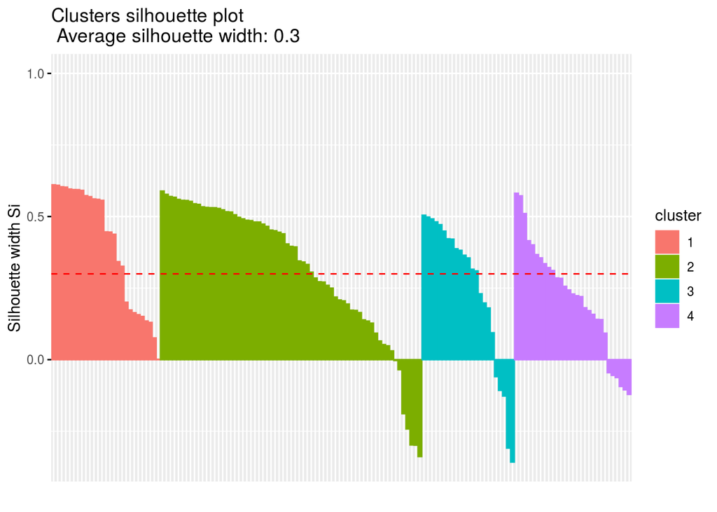

```r
fviz_silhouette(res.pam) ##silhouette plot to check fit for partition clustering
```

```r
pamEval=data.frame(res.pam$silinfo$widths)
head(pamEval) #makes a table of the widths to see where countries fall
```

```
##             cluster neighbor sil_width
## Denmark           1        3 0.6107752
## Austria           1        3 0.6089339
## Netherlands       1        3 0.6039116
## Sweden            1        3 0.6026696
## Belgium           1        3 0.5960109
## Finland           1        3 0.5941047
```

```r
pamEval[pamEval$sil_width<0,] #identify the negative width values to see which countries don't fit the clustering model
```

```
##                          cluster neighbor    sil_width
## Ukraine                        2        3 -0.002968464
## Tunisia                        2        3 -0.035063573
## Armenia                        2        3 -0.188773803
## Albania                        2        3 -0.242063987
## Bulgaria                       2        3 -0.297856732
## North Macedonia                2        3 -0.298710173
## Bosnia and Herzegovina         2        3 -0.338569573
## Maldives                       3        2 -0.059427642
## Slovenia                       3        1 -0.107374951
## Panama                         3        2 -0.127064606
## Botswana                       3        2 -0.309000649
## Dominican Republic             3        2 -0.357779594
## Central African Republic       4        2 -0.045567252
## Algeria                        4        2 -0.054917186
## Cambodia                       4        2 -0.062487371
## India                          4        2 -0.093720601
## Pakistan                       4        2 -0.105505160
## Myanmar                        4        2 -0.121304478
```

```r
library(factoextra)

res.agnes= hcut(dfClus1_D, k = NumCluster,isdiss=T,
                 hc_func='agnes',
                 hc_method = "ward.D2") #steps for bottom-up agnes method
```

```r
fromPy$agn=as.factor(res.agnes$cluster)
```

```r
table(fromPy$agn)
```

```
##
##  1  2  3  4
## 28 45 33 38
```

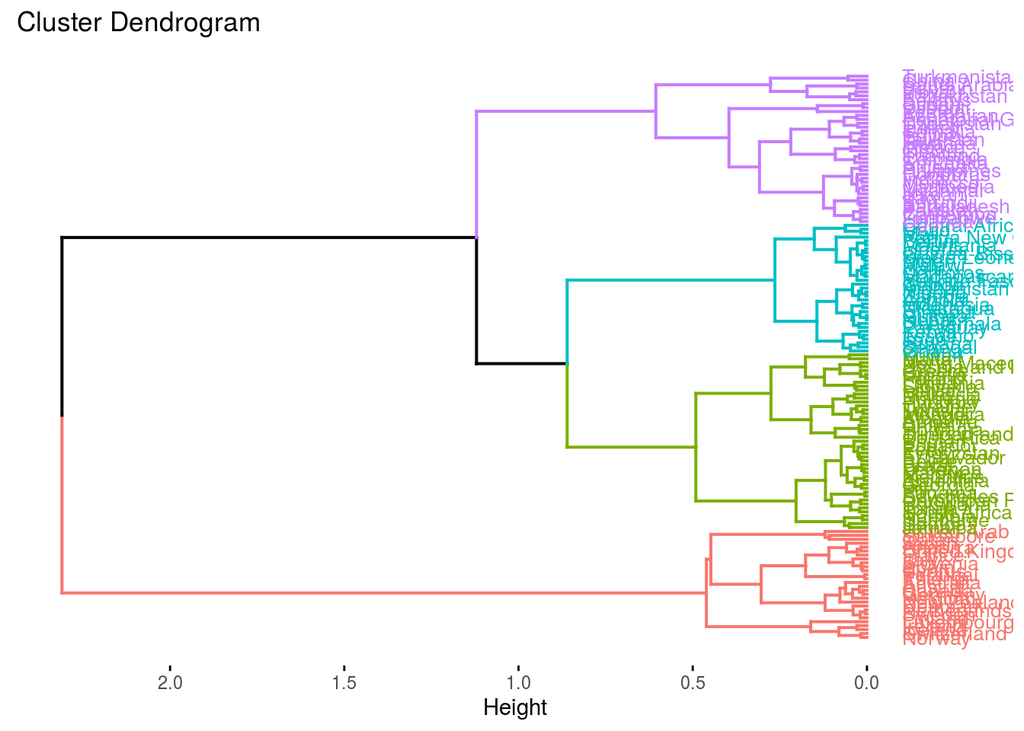

```r
fviz_dend(res.agnes,k=NumCluster, cex = 0.7, horiz = T) #creates agnes dendrogram
```

```
##   cluster size ave.sil.width
## 1       1   28          0.48
## 2       2   45          0.28
## 3       3   33          0.57
## 4       4   38          0.13
```

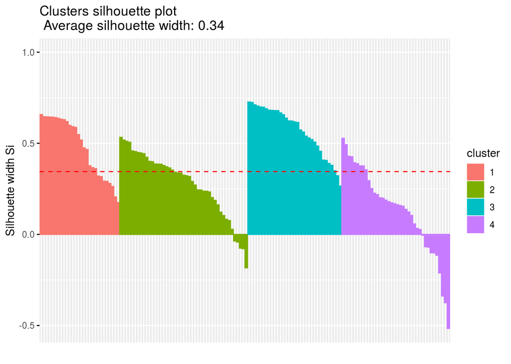

```r
library(factoextra)
fviz_silhouette(res.agnes) #checks the fit again but this time for agnes
```

```r
agnEval=data.frame(res.agnes$silinfo$widths)
head(agnEval) #repeats the steps made with other methods
```

```
##             cluster neighbor sil_width
## Austria           1        2 0.6579689
## Denmark           1        2 0.6460865
## Belgium           1        2 0.6453326
## Germany           1        2 0.6443465
## Netherlands       1        2 0.6435786
## Sweden            1        2 0.6414828
```

```r
agnEval[agnEval$sil_width<0,]
```

```
##                    cluster neighbor    sil_width
## Namibia                  2        3 -0.036015739
## Suriname                 2        3 -0.042466954
## Botswana                 2        3 -0.075575445
## Dominican Republic       2        3 -0.078237650
## Bhutan                   2        3 -0.183515417
## Yemen                    4        3 -0.004537604
## India                    4        3 -0.067630167
## Jordan                   4        3 -0.070335715
## Sri Lanka                4        2 -0.100656303
## Oman                     4        2 -0.101285169
## Morocco                  4        3 -0.114235032
## Pakistan                 4        3 -0.211689322
## Zimbabwe                 4        3 -0.338113282
## Cameroon                 4        3 -0.374695561
## Uganda                   4        3 -0.516339026
```

```r
library(factoextra)

res.diana= hcut(dfClus1_D, k = NumCluster,
                 hc_func='diana',
                 hc_method = "ward.D")
```

```r
fromPy$dia=as.factor(res.diana$cluster)
```

```r
table(fromPy$dia)
```

```
##
##  1  2  3  4
## 17 86 19 22
```

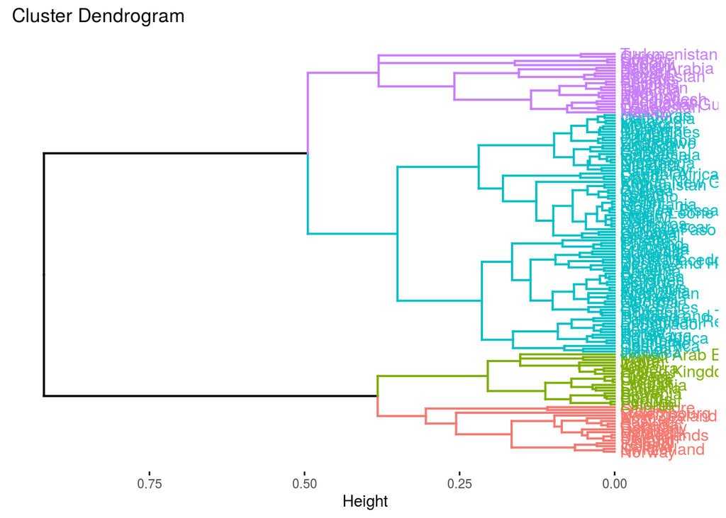

```r
fviz_dend(res.diana,k=NumCluster, cex = 0.8, horiz = T)
```

```
##   cluster size ave.sil.width
## 1       1   17          0.33
## 2       2   86          0.42
## 3       3   19          0.48
## 4       4   22          0.33
```

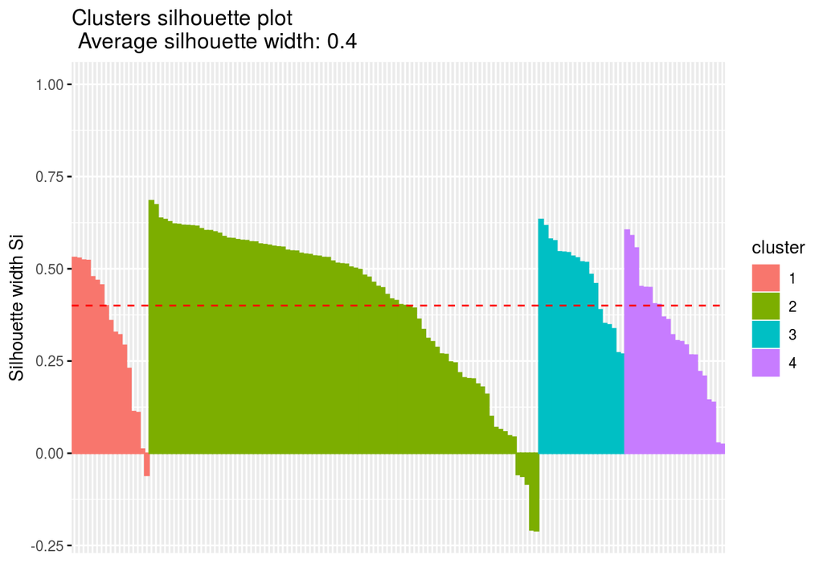

```r
library(factoextra)
fviz_silhouette(res.diana)
```

The countries included in the first group, marked in red on our dendrogram, are places like Norway, Finland, Sweden; typically richer Western countries with social democratic leanings. The only countries in this category that weren’t traditionally Western associated were Qatar and Singapore

```r
diaEval=data.frame(res.diana$silinfo$widths)
head(diaEval)
```

```
##             cluster neighbor sil_width
## Norway            1        3 0.5303512
## Switzerland       1        3 0.5282580
## Denmark           1        3 0.5233013
## Iceland           1        3 0.5222306
## Ireland           1        3 0.4779774
## Sweden            1        3 0.4681174
```

```r
diaEval[diaEval$sil_width<0,]
```

```
##                        cluster neighbor   sil_width
## New Zealand                  1        3 -0.05964885
## Costa Rica                   2        3 -0.05737438
## Chile                        2        3 -0.06218060
## Hungary                      2        3 -0.08333654
## North Macedonia              2        3 -0.20754633
## Bosnia and Herzegovina       2        3 -0.20973939
```

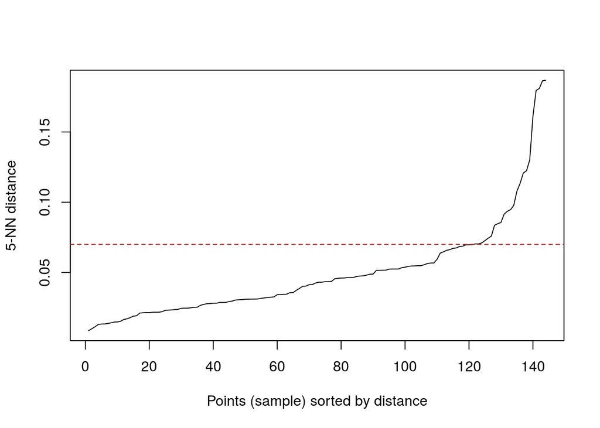

```r
library(dbscan)
#minNeighs> num cols in data
minNeighs=5
kNNdistplot(dfClus1_D, k = minNeighs)
abline(h=.07, col = "red", lty=2) #setting threshold
```

```r
distance=0.10
res.db = dbscan::dbscan(dfClus1_D, eps=distance,
                     minPts=minNeighs)
```

```r
res.db
```

```
## DBSCAN clustering for 144 objects.
## Parameters: eps = 0.1, minPts = 5
## The clustering contains 1 cluster(s) and 4 noise points.
##
##   0   1
##   4 140
##
## Available fields: cluster, eps, minPts
```

```r
fromPy$db=as.factor(res.db$cluster)
```

```r
projectedData = cmdscale(dfClus1_D, k=2)
#
# save coordinates to original data frame:
fromPy$dim1 = projectedData[,1]
fromPy$dim2 = projectedData[,2]
```

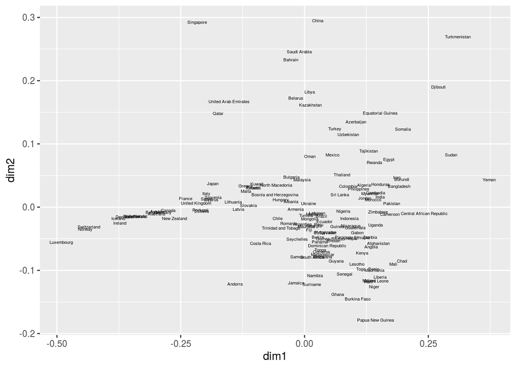

```r
base= ggplot(data=fromPy,
             aes(x=dim1, y=dim2,
                 label=Country))
base + geom_text(size=1.5) #dimensionality reduction for our countreis and variables
```

As demonstrated by our DIANA method dimensionality reduction graph, Singapore and Qatar were the only countries outside of the dense grouping from group one. At least for Singapore, we believe it does so well in both GDP and GII index values that it gets grouped into group one despite a terrible press freedom score. We suspect this is the case for other extreme outliers; that high values in one variable, most frequently GDP, skew the clustering algorithm to include a given country despite poor scores in other categories. Certainly, other extreme outliers like the United Arab Emirates, Saudi Arabia and China would seem to fit this description.

The second group had countries like Georgia, Mongolia, El Salvador and Tunisia and, generally, had much more geographic and political spread with far more outliers. Our third group had countries like Italy, France, the United Kingdom, Greece and countries associated with Western and Eastern Europe with notable outliers like the UAE. Many of the countries within this cluster were, interestingly, NATO member states. In the dimensionality reduction graph, this group was almost as dense as group one and located close to group one. Our fourth group had countries like Egypt, Saudi Arabia and China. We observed that the second and fourth group had many states in common with those that identified themselves as observers or members of the nonalignment movement of the Cold War surprisingly. As a result, we created the following names for defining the corresponding groups:

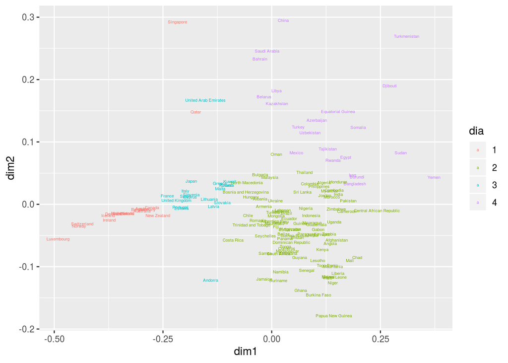

```r
base= ggplot(data=fromPy,
             aes(x=dim1, y=dim2,
                 label=Country, color=dia))
base + geom_text(size=1.5) #same as prior graph but color coded according to group
```

```r
pamPlot=base + labs(title = "PAM") + geom_point(size=2,
                                              aes(color=pam),
                                              show.legend = F)
```

```r
agnPlot=base + labs(title = "AGNES") + geom_point(size=2,
                                              aes(color=agn),
                                              show.legend = F)
```

```r
diaPlot=base + labs(title = "DIANA") + geom_point(size=2,
                                              aes(color=dia),
                                              show.legend = F)
```

```r
library(ggpubr)
```

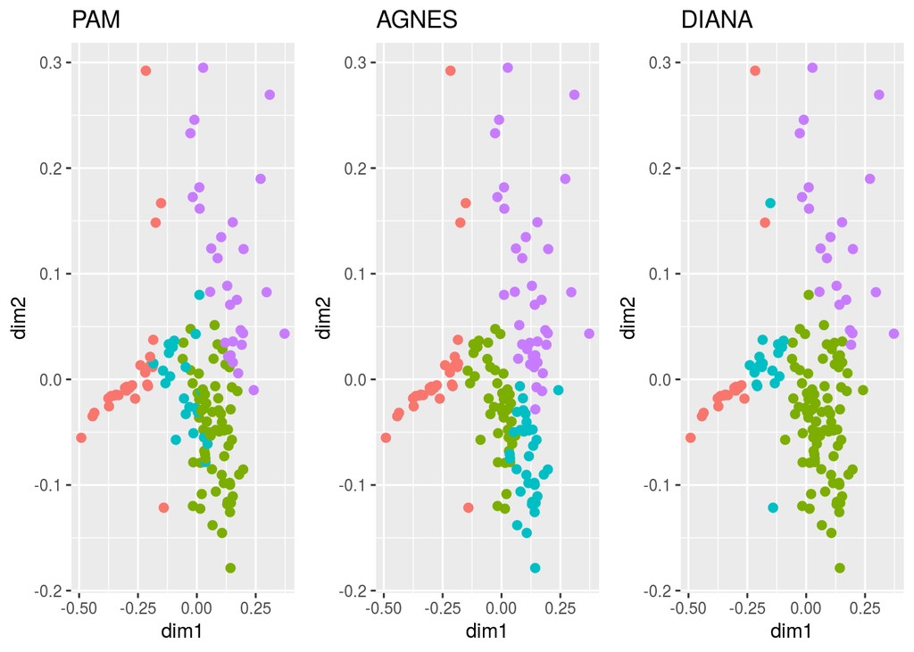

```r
ggarrange(pamPlot, agnPlot, diaPlot,ncol = 3) #compares different methods
```

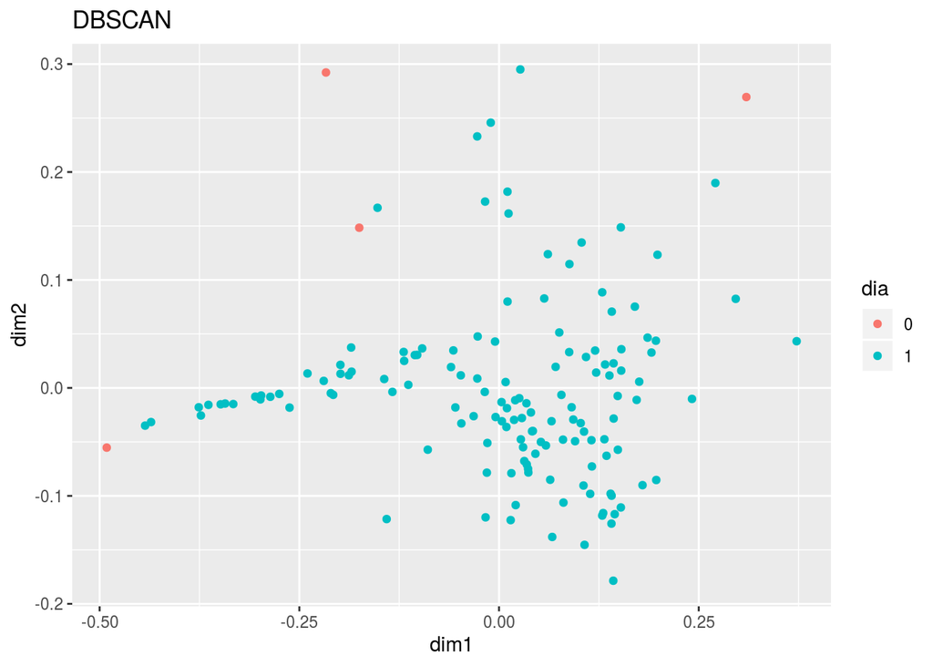

```r
dbPlot= base + labs(title = "DBSCAN") + geom_point(aes(color=db),
                                               show.legend = T)
dbPlot #identifies extreme outliers
```

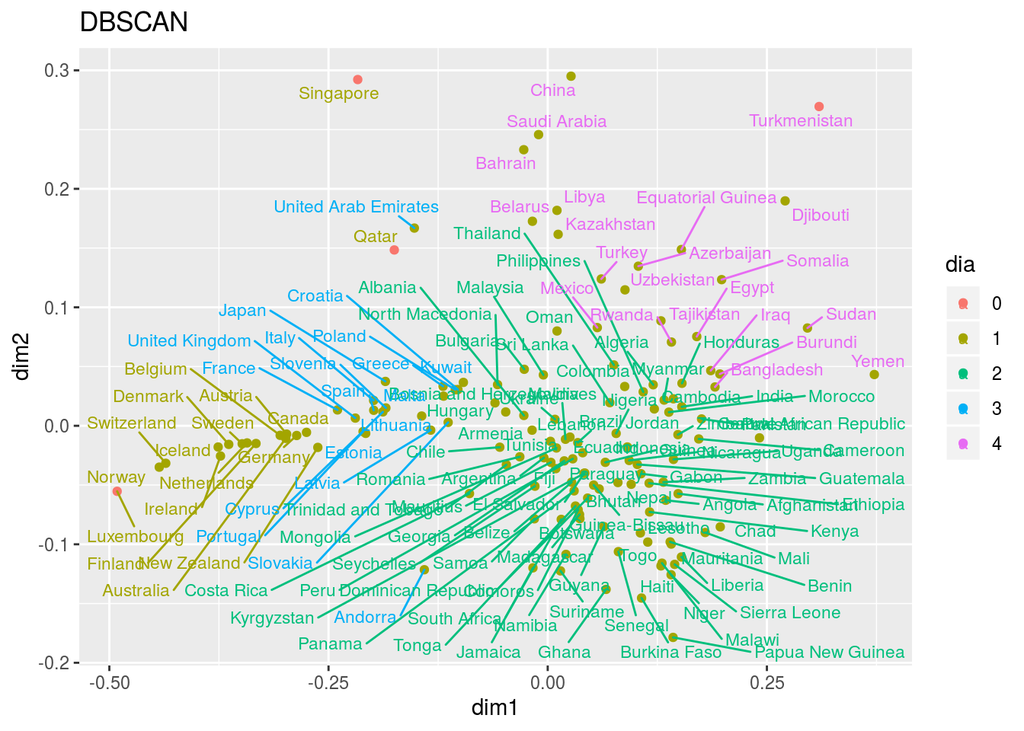

```r
library(ggrepel)
dbPlot + geom_text_repel(size=3,aes(label=Country))
```

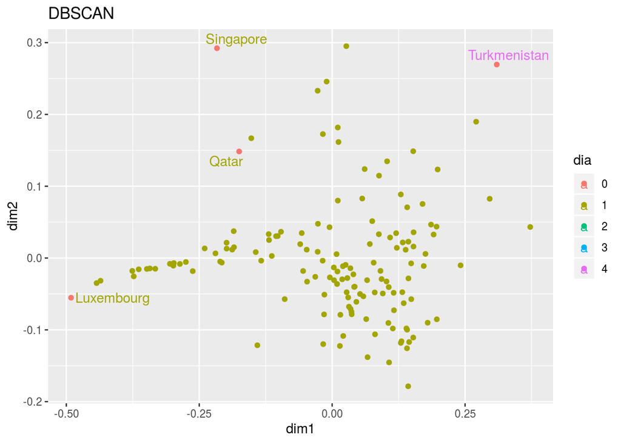

```r
LABEL=ifelse(fromPy$db==0,fromPy$Country,"")

dbPlot + geom_text_repel(aes(label=LABEL))
```

The continuous variables are centered at their means. This is common in multiple regression models that use interaction terms between continuous variables. By centering, the main effects of an interaction term estimate the impact of an explanatory variable on the dependent variable while holding all other explanatory variables constant at their mean (instead of at zero, as is the case with non-centered data).All explanatory variables are centered in all regressions, and dependent variables are not centered.

```r
# Create mean-centered versions of three variables
GII_scaled <- scale(fromPy$GiiIndex2018, scale=F)
GDP_scaled <- scale(fromPy$GDPpercapita,scale=F)
PF_scaled <- scale(fromPy$PressFreedomScore, scale = F)
```

### Regression Model 1

Gender Inequality Index as a function of the interaction between GDP per capita and Press Freedom along with their main effects.

#### Hypothesis:

Countries with more press freedom and higher GDP will have more gender equality. Richer countries will have a higher impact of Press Freedom on GII.

#### Rationale:

- Higher economic development as measured by GDP means more opportunities for women, lowering GII. (-)
- More press freedom means more representation of women’s views on media, increasing gender equality. (+)
- Richer countries have more developed media infrastructure, allowing higher impact of PF on GII. (+)

#### Discussion:

The interaction term coefficient is significant at the 10% level and is negative, contrary to the hypothesis. This means that as a country grows richer, the ability of freedom of the press to improve gender equality diminishes. Special interests could grow larger and more powerful as a country grows in wealth, and this would lead to less opportunities for women. The GDP coefficient is significant at the 5% level and is the predicted sign. The R-squared is about 54%, which is above Model 2 and below Model 3.

```r
Gii_Model<-lm(fromPy$GiiIndex2018~GDP_scaled*PF_scaled )
summary(Gii_Model)
```

```
##
## Call:
## lm(formula = fromPy$GiiIndex2018 ~ GDP_scaled * PF_scaled)
##
## Residuals:
##      Min       1Q   Median       3Q      Max
## -0.30977 -0.07668 -0.00319  0.08115  0.33997
##
## Coefficients:
##                        Estimate Std. Error t value Pr(>|t|)
## (Intercept)           3.395e-01  1.273e-02  26.681   <2e-16 ***
## GDP_scaled           -7.399e-06  7.722e-07  -9.582   <2e-16 ***
## PF_scaled             6.056e-04  9.246e-04   0.655    0.514
## GDP_scaled:PF_scaled -8.244e-08  4.203e-08  -1.962    0.052 .
## ---
## Signif. codes:  0 '***' 0.001 '**' 0.01 '*' 0.05 '.' 0.1 ' ' 1
##
## Residual standard error: 0.1322 on 129 degrees of freedom
##   (11 observations deleted due to missingness)
## Multiple R-squared:  0.5491, Adjusted R-squared:  0.5386
## F-statistic: 52.37 on 3 and 129 DF,  p-value: < 2.2e-16
```

```r
shapiro.test(Gii_Model$residuals) # Test for normality of residuals
```

```
##
##  Shapiro-Wilk normality test
##
## data:  Gii_Model$residuals
## W = 0.99204, p-value = 0.6566
```

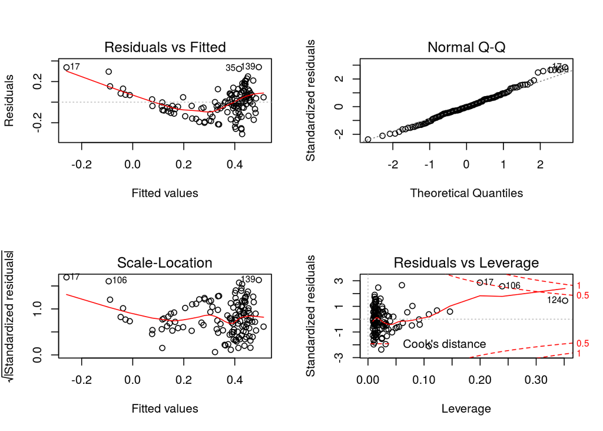

```r
par(mfrow = c(2, 2))
plot(Gii_Model) # Show regression diagnostic plots
```

#### Within Cluster:

No significant results came were produced from running the model, centered and non-centered, in each of the clusters made by DIANA.

```r
# Model 1 in each of the four groups made by DIANA.
# Group 1
subset1 = subset(fromPy, fromPy$dia == 1)
y1 = lm(subset1$GiiIndex2018 ~ subset1$GDPpercapita*subset1$PressFreedomScore, data = subset1)
summary(y1)
```

```
##
## Call:
## lm(formula = subset1$GiiIndex2018 ~ subset1$GDPpercapita * subset1$PressFreedomScore,
##     data = subset1)
##
## Residuals:
##       Min        1Q    Median        3Q       Max
## -0.061374 -0.028706 -0.005247  0.019726  0.059160
##
## Coefficients:
##                                                  Estimate Std. Error t value
## (Intercept)                                     2.748e-01  1.431e-01   1.921
## subset1$GDPpercapita                           -3.582e-06  2.214e-06  -1.618
## subset1$PressFreedomScore                      -1.436e-02  1.039e-02  -1.382
## subset1$GDPpercapita:subset1$PressFreedomScore  2.473e-07  1.580e-07   1.565
##                                                Pr(>|t|)
## (Intercept)                                       0.077 .
## subset1$GDPpercapita                              0.130
## subset1$PressFreedomScore                         0.190
## subset1$GDPpercapita:subset1$PressFreedomScore    0.142
## ---
## Signif. codes:  0 '***' 0.001 '**' 0.01 '*' 0.05 '.' 0.1 ' ' 1
##
## Residual standard error: 0.03665 on 13 degrees of freedom
## Multiple R-squared:  0.3918, Adjusted R-squared:  0.2514
## F-statistic: 2.791 on 3 and 13 DF,  p-value: 0.08229
```

```r
# Group 2
subset2 = subset(fromPy, fromPy$dia == 2)
y2 = lm(subset2$GiiIndex2018 ~ subset2$GDPpercapita*subset2$PressFreedomScore, data = subset2)
summary(y2)
```

```
##
## Call:
## lm(formula = subset2$GiiIndex2018 ~ subset2$GDPpercapita * subset2$PressFreedomScore,
##     data = subset2)
##
## Residuals:
##       Min        1Q    Median        3Q       Max
## -0.281499 -0.048839  0.008889  0.049839  0.254565
##
## Coefficients:
##                                                  Estimate Std. Error t value
## (Intercept)                                     5.054e-01  8.046e-02   6.282
## subset2$GDPpercapita                           -1.361e-05  1.187e-05  -1.147
## subset2$PressFreedomScore                       1.153e-03  2.337e-03   0.493
## subset2$GDPpercapita:subset2$PressFreedomScore -1.691e-07  3.688e-07  -0.459
##                                                Pr(>|t|)
## (Intercept)                                    1.91e-08 ***
## subset2$GDPpercapita                              0.255
## subset2$PressFreedomScore                         0.623
## subset2$GDPpercapita:subset2$PressFreedomScore    0.648
## ---
## Signif. codes:  0 '***' 0.001 '**' 0.01 '*' 0.05 '.' 0.1 ' ' 1
##
## Residual standard error: 0.101 on 76 degrees of freedom
##   (6 observations deleted due to missingness)
## Multiple R-squared:  0.4047, Adjusted R-squared:  0.3812
## F-statistic: 17.22 on 3 and 76 DF,  p-value: 1.256e-08
```

```r
# Group 3
subset3 = subset(fromPy, fromPy$dia == 3)
y3 = lm(subset3$GiiIndex2018 ~ subset3$GDPpercapita*subset3$PressFreedomScore, data = subset3)
summary(y3)
```

```
##
## Call:
## lm(formula = subset3$GiiIndex2018 ~ subset3$GDPpercapita * subset3$PressFreedomScore,
##     data = subset3)
##
## Residuals:
##      Min       1Q   Median       3Q      Max
## -0.04523 -0.03253 -0.01726  0.02970  0.10835
##
## Coefficients:
##                                                  Estimate Std. Error t value
## (Intercept)                                     1.120e-01  1.526e-01   0.734
## subset3$GDPpercapita                           -2.674e-06  4.973e-06  -0.538
## subset3$PressFreedomScore                       2.403e-03  5.848e-03   0.411
## subset3$GDPpercapita:subset3$PressFreedomScore  3.005e-08  1.785e-07   0.168
##                                                Pr(>|t|)
## (Intercept)                                       0.475
## subset3$GDPpercapita                              0.599
## subset3$PressFreedomScore                         0.687
## subset3$GDPpercapita:subset3$PressFreedomScore    0.869
##
## Residual standard error: 0.04928 on 14 degrees of freedom
##   (1 observation deleted due to missingness)
## Multiple R-squared:  0.2383, Adjusted R-squared:  0.07513
## F-statistic:  1.46 on 3 and 14 DF,  p-value: 0.2679
```

```r
# Group 4
subset4 = subset(fromPy, fromPy$dia == 4)
y4 = lm(subset4$GiiIndex2018 ~ subset4$GDPpercapita*subset4$PressFreedomScore, data = subset4)
summary(y4)
```

```
##
## Call:
## lm(formula = subset4$GiiIndex2018 ~ subset4$GDPpercapita * subset4$PressFreedomScore,
##     data = subset4)
##
## Residuals:
##      Min       1Q   Median       3Q      Max
## -0.24082 -0.11180  0.00240  0.09032  0.36592
##
## Coefficients:
##                                                  Estimate Std. Error t value
## (Intercept)                                     1.936e-01  5.216e-01   0.371
## subset4$GDPpercapita                            4.924e-06  6.514e-05   0.076
## subset4$PressFreedomScore                       4.687e-03  8.943e-03   0.524
## subset4$GDPpercapita:subset4$PressFreedomScore -3.288e-07  1.058e-06  -0.311
##                                                Pr(>|t|)
## (Intercept)                                       0.716
## subset4$GDPpercapita                              0.941
## subset4$PressFreedomScore                         0.608
## subset4$GDPpercapita:subset4$PressFreedomScore    0.760
##
## Residual standard error: 0.1651 on 14 degrees of freedom
##   (4 observations deleted due to missingness)
## Multiple R-squared:  0.3326, Adjusted R-squared:  0.1896
## F-statistic: 2.326 on 3 and 14 DF,  p-value: 0.1191
```

### Regression Model 2

Press Freedom as a function of the interaction between GDP per capita and Gender Inequality Index along with their main effects.

#### Hypothesis:

Higher GDP and more gender equality leads to more press freedom. The impact of gender equality on press freedom will be greater for richer countries.

#### Rationale:

- Higher GDP means more opportunities for media firms to succeed. (-)
- Greater gender equality leads to women being represented more in media, leading to more diverse opinions in media. (+)
- Richer countries have more opportunities for women, leading to more representation in media, increasing press freedom. (+)

#### Discussion:

The GDP coefficient is significant at the 5% level, yet the interaction term or GII coefficient are not. All three coefficients are the predicted sign. However, the R-squared is only 20%, which is the lowest explanatory power of the three models.

```r
PF_Model<-lm(fromPy$PressFreedomScore ~ fromPy$GDPpercapita*fromPy$GiiIndex2018)
summary(PF_Model)
```

```
##
## Call:
## lm(formula = fromPy$PressFreedomScore ~ fromPy$GDPpercapita *
##     fromPy$GiiIndex2018)
##
## Residuals:
##     Min      1Q  Median      3Q     Max
## -25.044  -7.632  -3.300   6.555  45.908
##
## Coefficients:
##                                           Estimate Std. Error t value Pr(>|t|)
## (Intercept)                              3.388e+01  4.002e+00   8.464  4.9e-14
## fromPy$GDPpercapita                     -3.364e-04  8.722e-05  -3.857  0.00018
## fromPy$GiiIndex2018                      4.370e+00  8.178e+00   0.534  0.59402
## fromPy$GDPpercapita:fromPy$GiiIndex2018  1.074e-03  7.124e-04   1.507  0.13426
##
## (Intercept)                             ***
## fromPy$GDPpercapita                     ***
## fromPy$GiiIndex2018
## fromPy$GDPpercapita:fromPy$GiiIndex2018
## ---
## Signif. codes:  0 '***' 0.001 '**' 0.01 '*' 0.05 '.' 0.1 ' ' 1
##
## Residual standard error: 12.47 on 129 degrees of freedom
##   (11 observations deleted due to missingness)
## Multiple R-squared:  0.2269, Adjusted R-squared:  0.209
## F-statistic: 12.62 on 3 and 129 DF,  p-value: 2.742e-07
```

```r
shapiro.test(PF_Model$residuals) # Test for normality of residuals
```

```
##
##  Shapiro-Wilk normality test
##
## data:  PF_Model$residuals
## W = 0.92451, p-value = 1.555e-06
```

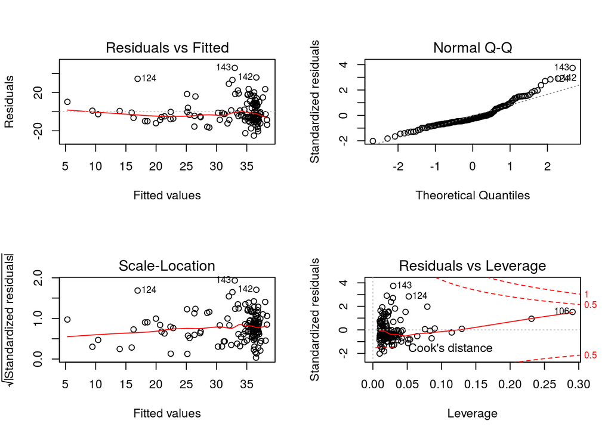

```r
par(mfrow = c(2, 2))
plot(PF_Model) # Show regression diagnostic plots
```

#### Within Cluster:

Running the model in Group 4 produced the only significant result. The interaction term coefficient is significant at the 10% level and negative, which is the opposite of the predicted sign. This indicates that as GDP grows, the impact of gender equality on press freedom diminishes. The GDP coefficient is significant at the 5% level and is the opposite sign predicted. Group 4 consists of mainly countries with low freedom of press and gender equality, which could mean the richer of these countries have less opportunities for women, worsening women representation in the press. The R-squared is only about 13%, so this model has poor explanatory power.

```r
# Group 1
x1 = lm(subset1$PressFreedomScore ~ subset1$GDPpercapita*subset1$GiiIndex2018, data=subset1)
summary(x1)
```

```
##
## Call:
## lm(formula = subset1$PressFreedomScore ~ subset1$GDPpercapita *
##     subset1$GiiIndex2018, data = subset1)
##
## Residuals:
##    Min     1Q Median     3Q    Max
## -6.731 -4.263 -1.916  0.151 36.299
##
## Coefficients:
##                                             Estimate Std. Error t value
## (Intercept)                                2.788e+01  2.936e+01   0.950
## subset1$GDPpercapita                      -3.511e-04  4.491e-04  -0.782
## subset1$GiiIndex2018                      -2.184e+02  3.667e+02  -0.596
## subset1$GDPpercapita:subset1$GiiIndex2018  5.741e-03  5.648e-03   1.017
##                                           Pr(>|t|)
## (Intercept)                                  0.360
## subset1$GDPpercapita                         0.448
## subset1$GiiIndex2018                         0.562
## subset1$GDPpercapita:subset1$GiiIndex2018    0.328
##
## Residual standard error: 10.87 on 13 degrees of freedom
## Multiple R-squared:  0.3371, Adjusted R-squared:  0.1842
## F-statistic: 2.204 on 3 and 13 DF,  p-value: 0.1364
```

```r
# Group 2
x2 = lm(subset2$PressFreedomScore ~ subset2$GDPpercapita*subset2$GiiIndex2018, data=subset2)
summary(x2)
```

```
##
## Call:
## lm(formula = subset2$PressFreedomScore ~ subset2$GDPpercapita *
##     subset2$GiiIndex2018, data = subset2)
##
## Residuals:
##     Min      1Q  Median      3Q     Max
## -20.723  -4.342  -0.949   4.257  15.579
##
## Coefficients:
##                                             Estimate Std. Error t value
## (Intercept)                               32.4313180  5.7741467   5.617
## subset2$GDPpercapita                      -0.0001107  0.0008353  -0.133
## subset2$GiiIndex2018                       4.4683551 11.0579662   0.404
## subset2$GDPpercapita:subset2$GiiIndex2018 -0.0008276  0.0021413  -0.386
##                                           Pr(>|t|)
## (Intercept)                               3.05e-07 ***
## subset2$GDPpercapita                         0.895
## subset2$GiiIndex2018                         0.687
## subset2$GDPpercapita:subset2$GiiIndex2018    0.700
## ---
## Signif. codes:  0 '***' 0.001 '**' 0.01 '*' 0.05 '.' 0.1 ' ' 1
##
## Residual standard error: 7.861 on 76 degrees of freedom
##   (6 observations deleted due to missingness)
## Multiple R-squared:  0.06174,    Adjusted R-squared:  0.0247
## F-statistic: 1.667 on 3 and 76 DF,  p-value: 0.1812
```

```r
# Group 3
x3 = lm(subset3$PressFreedomScore ~ subset3$GDPpercapita*subset3$GiiIndex2018, data=subset3)
summary(x3)
```

```
##
## Call:
## lm(formula = subset3$PressFreedomScore ~ subset3$GDPpercapita *
##     subset3$GiiIndex2018, data = subset3)
##
## Residuals:
##     Min      1Q  Median      3Q     Max
## -9.4571 -2.7157 -0.8585  1.8191 14.1826
##
## Coefficients:
##                                            Estimate Std. Error t value Pr(>|t|)
## (Intercept)                               1.030e+01  1.958e+01   0.526    0.607
## subset3$GDPpercapita                      2.643e-04  6.104e-04   0.433    0.672
## subset3$GiiIndex2018                      4.775e+01  1.537e+02   0.311    0.761
## subset3$GDPpercapita:subset3$GiiIndex2018 4.913e-04  4.909e-03   0.100    0.922
##
## Residual standard error: 6.758 on 14 degrees of freedom
##   (1 observation deleted due to missingness)
## Multiple R-squared:  0.2997, Adjusted R-squared:  0.1496
## F-statistic: 1.997 on 3 and 14 DF,  p-value: 0.1608
```

```r
# Group 4
x4 = lm(subset4$PressFreedomScore ~ subset4$GDPpercapita*subset4$GiiIndex2018, data=subset4)
summary(x4)
```

```
##
## Call:
## lm(formula = subset4$PressFreedomScore ~ subset4$GDPpercapita *
##     subset4$GiiIndex2018, data = subset4)
##
## Residuals:
##    Min     1Q Median     3Q    Max
## -6.520 -5.136 -1.726  2.217 18.596
##
## Coefficients:
##                                             Estimate Std. Error t value
## (Intercept)                               47.5296113  6.6240302   7.175
## subset4$GDPpercapita                       0.0021427  0.0009365   2.288
## subset4$GiiIndex2018                      23.5736467 14.8791524   1.584
## subset4$GDPpercapita:subset4$GiiIndex2018 -0.0075249  0.0037656  -1.998
##                                           Pr(>|t|)
## (Intercept)                               4.74e-06 ***
## subset4$GDPpercapita                        0.0382 *
## subset4$GiiIndex2018                        0.1354
## subset4$GDPpercapita:subset4$GiiIndex2018   0.0655 .
## ---
## Signif. codes:  0 '***' 0.001 '**' 0.01 '*' 0.05 '.' 0.1 ' ' 1
##
## Residual standard error: 7.609 on 14 degrees of freedom
##   (4 observations deleted due to missingness)
## Multiple R-squared:  0.2814, Adjusted R-squared:  0.1275
## F-statistic: 1.828 on 3 and 14 DF,  p-value: 0.1884
```

### Regression Model 3

GDP per capita as a function of the interaction between Press Freedom and Gender Inequality Index along with their main effects.

#### Hypothesis:

Countries with higher Press Freedom and Gender Inequality Index will have less GDP per Capita than countries with lower PF and GII. The impact of Press Freedom on GDP is greater the more gender equality is present.

#### Rationale:

- Worse media infrastructure and freedom leads to less economic development via less foreign investment, less information for businesses to make decisions. (-)
- More gender inequality means less opportunity for half the population, forgoing potential GDP. (-)
- Countries with more gender equality have more women representation in media, which empowers women and leads to more opportunities for potential GDP. (+)

#### Discussion:

Both transformed and non-transformed regression will be discussed. The non-transformed regression yielded all significant results at the 5% level, with all the predicted coefficient signs. This model has an R-squared of about 62%. The transformed regression yielded only significant results for the main effects, and has an R-squared of about 77%. The signs on the coefficients remained unchanged under the transformation.

```r
GDP_Model<-lm(fromPy$GDPpercapita ~ PF_scaled*GII_scaled)
summary(GDP_Model)
```

```
##
## Call:
## lm(formula = fromPy$GDPpercapita ~ PF_scaled * GII_scaled)
##
## Residuals:
##    Min     1Q Median     3Q    Max
## -23393  -6160  -1646   3530  69655
##
## Coefficients:
##                       Estimate Std. Error t value Pr(>|t|)
## (Intercept)           13676.39    1212.69  11.278  < 2e-16 ***
## PF_scaled              -222.85      91.89  -2.425   0.0167 *
## GII_scaled           -67921.12    6403.08 -10.608  < 2e-16 ***
## PF_scaled:GII_scaled   1845.47     419.30   4.401 2.23e-05 ***
## ---
## Signif. codes:  0 '***' 0.001 '**' 0.01 '*' 0.05 '.' 0.1 ' ' 1
##
## Residual standard error: 13190 on 129 degrees of freedom
##   (11 observations deleted due to missingness)
## Multiple R-squared:  0.6316, Adjusted R-squared:  0.6231
## F-statistic: 73.74 on 3 and 129 DF,  p-value: < 2.2e-16
```

```r
shapiro.test(GDP_Model$residuals) # Test for normality of residuals
```

```
##
##  Shapiro-Wilk normality test
##
## data:  GDP_Model$residuals
## W = 0.83991, p-value = 1.029e-10
```

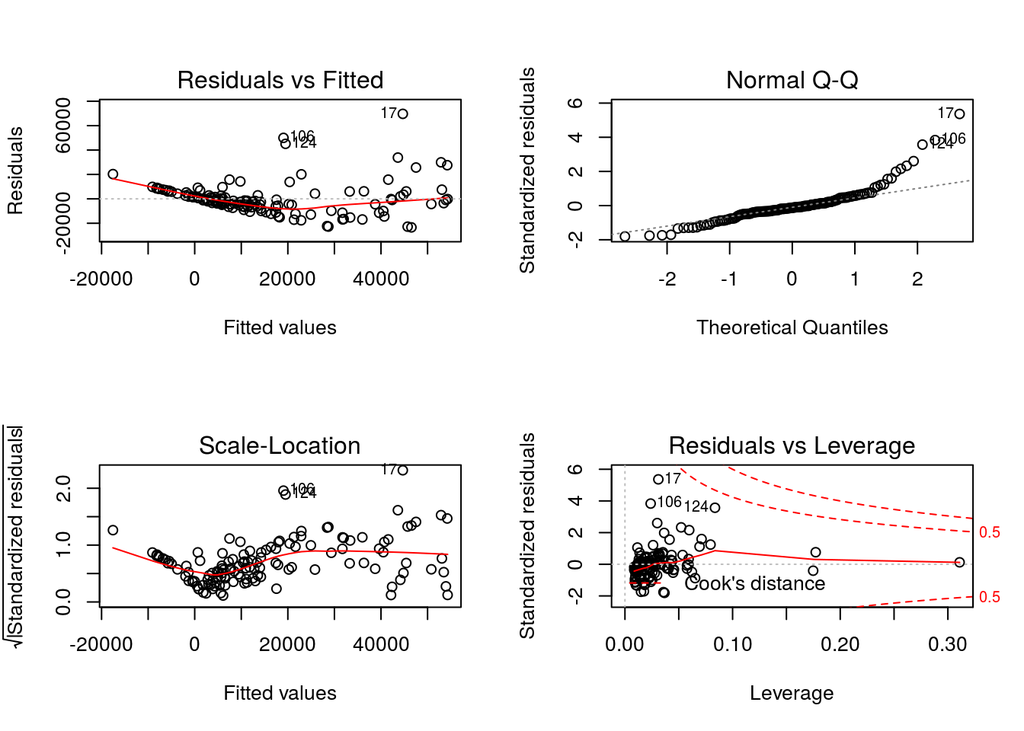

```r
par(mfrow = c(2, 2))
plot(GDP_Model)
```

```r
# Natural log transformation of GDP per Capita model
z<-lm(log(fromPy$GDPpercapita) ~ PF_scaled*GII_scaled)
summary(z)
```

```
##
## Call:
## lm(formula = log(fromPy$GDPpercapita) ~ PF_scaled * GII_scaled)
##
## Residuals:
##      Min       1Q   Median       3Q      Max
## -1.56052 -0.38371  0.00915  0.46685  1.67726
##
## Coefficients:
##                      Estimate Std. Error t value Pr(>|t|)
## (Intercept)           8.71981    0.06401 136.230  < 2e-16 ***
## PF_scaled            -0.01274    0.00485  -2.627  0.00967 **
## GII_scaled           -6.12143    0.33797 -18.112  < 2e-16 ***
## PF_scaled:GII_scaled  0.01617    0.02213   0.731  0.46629
## ---
## Signif. codes:  0 '***' 0.001 '**' 0.01 '*' 0.05 '.' 0.1 ' ' 1
##
## Residual standard error: 0.6963 on 129 degrees of freedom
##   (11 observations deleted due to missingness)
## Multiple R-squared:  0.7763, Adjusted R-squared:  0.7711
## F-statistic: 149.2 on 3 and 129 DF,  p-value: < 2.2e-16
```

```r
shapiro.test(z$residuals) # Test for normality of residuals
```

```
##
##  Shapiro-Wilk normality test
##
## data:  z$residuals
## W = 0.9883, p-value = 0.3214
```

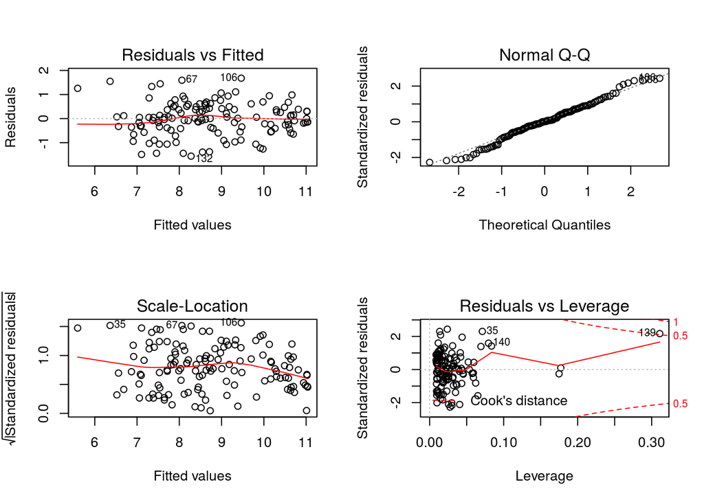

```r
par(mfrow = c(2, 2))
plot(z)
```

#### Within Cluster:

The transformed model in Group 3 is the only one to yield significant results. The GII coefficient is significant at the 10% level, and the predicted sign, with an R-squared of about 14%. Group 3 consists of mostly western european countries that are similar to Group 1. Countries in this group have similar impacts of GII on GDP per capita compared to all countries as a whole (since Model 3 used the whole data set). Both the transformed and non-transformed model was used in all groups, and the non-transformed model yielded no significant results.

```r
# Group 1
z1 = lm(log(subset1$GDPpercapita) ~ subset1$PressFreedomScore*subset1$GiiIndex2018, data = subset1)
summary(z1)
```

```
##
## Call:
## lm(formula = log(subset1$GDPpercapita) ~ subset1$PressFreedomScore *
##     subset1$GiiIndex2018, data = subset1)
##
## Residuals:
##      Min       1Q   Median       3Q      Max
## -0.29918 -0.17550 -0.06669  0.17476  0.66253
##
## Coefficients:
##                                                 Estimate Std. Error t value
## (Intercept)                                    11.183776   0.265800  42.076
## subset1$PressFreedomScore                      -0.002191   0.011666  -0.188
## subset1$GiiIndex2018                           -3.523089   3.710695  -0.949
## subset1$PressFreedomScore:subset1$GiiIndex2018  0.089850   0.114328   0.786
##                                                Pr(>|t|)
## (Intercept)                                    2.79e-15 ***
## subset1$PressFreedomScore                         0.854
## subset1$GiiIndex2018                              0.360
## subset1$PressFreedomScore:subset1$GiiIndex2018    0.446
## ---
## Signif. codes:  0 '***' 0.001 '**' 0.01 '*' 0.05 '.' 0.1 ' ' 1
##
## Residual standard error: 0.2827 on 13 degrees of freedom
## Multiple R-squared:  0.08591,    Adjusted R-squared:  -0.125
## F-statistic: 0.4073 on 3 and 13 DF,  p-value: 0.7504
```

```r
# Group 2
z2 = lm(log(subset2$GDPpercapita) ~ subset2$PressFreedomScore*subset2$GiiIndex2018, data = subset2)
summary(z2)
```

```
##
## Call:
## lm(formula = log(subset2$GDPpercapita) ~ subset2$PressFreedomScore *
##     subset2$GiiIndex2018, data = subset2)
##
## Residuals:
##      Min       1Q   Median       3Q      Max
## -1.58626 -0.41967  0.06013  0.47297  1.58915
##
## Coefficients:
##                                                Estimate Std. Error t value
## (Intercept)                                     9.91890    1.42577   6.957
## subset2$PressFreedomScore                       0.02474    0.04515   0.548
## subset2$GiiIndex2018                           -3.05206    3.12560  -0.976
## subset2$PressFreedomScore:subset2$GiiIndex2018 -0.08669    0.09732  -0.891
##                                                Pr(>|t|)
## (Intercept)                                    1.06e-09 ***
## subset2$PressFreedomScore                         0.585
## subset2$GiiIndex2018                              0.332
## subset2$PressFreedomScore:subset2$GiiIndex2018    0.376
## ---
## Signif. codes:  0 '***' 0.001 '**' 0.01 '*' 0.05 '.' 0.1 ' ' 1
##
## Residual standard error: 0.6856 on 76 degrees of freedom
##   (6 observations deleted due to missingness)
## Multiple R-squared:  0.5698, Adjusted R-squared:  0.5528
## F-statistic: 33.55 on 3 and 76 DF,  p-value: 6.424e-14
```

```r
# Group 3
z3 = lm(log(subset3$GDPpercapita) ~ subset3$PressFreedomScore*subset3$GiiIndex2018, data = subset3)
summary(z3)
```

```
##
## Call:
## lm(formula = log(subset3$GDPpercapita) ~ subset3$PressFreedomScore *
##     subset3$GiiIndex2018, data = subset3)
##
## Residuals:
##      Min       1Q   Median       3Q      Max
## -0.60373 -0.13063  0.05564  0.16022  0.59022
##
## Coefficients:
##                                                 Estimate Std. Error t value
## (Intercept)                                     11.25656    0.86363  13.034
## subset3$PressFreedomScore                       -0.02950    0.03278  -0.900
## subset3$GiiIndex2018                           -14.07972    7.72224  -1.823
## subset3$PressFreedomScore:subset3$GiiIndex2018   0.43156    0.27484   1.570
##                                                Pr(>|t|)
## (Intercept)                                    3.21e-09 ***
## subset3$PressFreedomScore                        0.3833
## subset3$GiiIndex2018                             0.0897 .
## subset3$PressFreedomScore:subset3$GiiIndex2018   0.1387
## ---
## Signif. codes:  0 '***' 0.001 '**' 0.01 '*' 0.05 '.' 0.1 ' ' 1
##
## Residual standard error: 0.3231 on 14 degrees of freedom
##   (1 observation deleted due to missingness)
## Multiple R-squared:  0.2932, Adjusted R-squared:  0.1418
## F-statistic: 1.936 on 3 and 14 DF,  p-value: 0.1702
```

```r
# Group 4
z4 = lm(log(subset4$GDPpercapita) ~ subset4$PressFreedomScore*subset4$GiiIndex2018, data = subset4)
summary(z4)
```

```
##
## Call:
## lm(formula = log(subset4$GDPpercapita) ~ subset4$PressFreedomScore *
##     subset4$GiiIndex2018, data = subset4)
##
## Residuals:
##      Min       1Q   Median       3Q      Max
## -1.43654 -0.51636  0.04816  0.77145  1.30828
##
## Coefficients:
##                                                Estimate Std. Error t value
## (Intercept)                                     7.95344    3.84323   2.069
## subset4$PressFreedomScore                       0.03217    0.06327   0.508
## subset4$GiiIndex2018                           -1.87266   10.65242  -0.176
## subset4$PressFreedomScore:subset4$GiiIndex2018 -0.04449    0.17575  -0.253
##                                                Pr(>|t|)
## (Intercept)                                      0.0575 .
## subset4$PressFreedomScore                        0.6191
## subset4$GiiIndex2018                             0.8630
## subset4$PressFreedomScore:subset4$GiiIndex2018   0.8039
## ---
## Signif. codes:  0 '***' 0.001 '**' 0.01 '*' 0.05 '.' 0.1 ' ' 1
##
## Residual standard error: 0.9892 on 14 degrees of freedom
##   (4 observations deleted due to missingness)
## Multiple R-squared:  0.4755, Adjusted R-squared:  0.363
## F-statistic:  4.23 on 3 and 14 DF,  p-value: 0.02522
```